# Social Networks: Theories and Methods RI-SP093 Final assignment

Marcelo Piemonte Ribeiro

12/23/2021

### Financial support links between Red Cross and Red Crescent (RCRC) National Societies (NSs) 2017-2020

Currently, there are 192 RCRC NSs which form a large humanitarian network. Yearly, NSs provide support links (at least U$1,000) to each other. NSs report to [IFRC Secretariat](https://www.ifrc.org/) via [FDRS team](https://data.ifrc.org/fdrs) this information and other data characterizing their structure (e.g., their yearly income, n° staff and volunteers, etc.)

### Research question/Hypothesis

NSs located in high income countries are key players in the network providing a lot of support links to other NSs. Anecdotal evidence highlights that pull factors also play a role in attracting support - such as characteristics of the receiving NSs (i.e. compliance in place), whether NS is under pressure (e.g. facing a natural disaster) and if NSs are from the same geographical region (for example NSs from MENA region tend to support relatively more those from the same region). Therefore, four main hypothesis can be raised:

**Hypothesis 1**: NSs facing emergencies tend to receive more support links (higher indegree).

**Hypothesis 2**: NSs reporting audited financial statements demonstrate financial integrity and are more likely to receive support from others.

**Hypothesis 3**: Rich (with either higher income in CHF or located in high income countries) NSs are more likely to support others.

**Hypothesis 4**: NSs in the same region are more likely to support each other.

### Data sample and visualization

The data available contains the unique support links between at least 184 NSs in four consecutive waves in 2017, 2018, 2019 and 2020. Also, it has yearly NSs total income (CHF), whether they reported audited financial statements and categorical variables indicating NS’s respective regions as well as if they were facing an extreme, “mild” or no disaster in the given years. Data limitation relates to NSs data capacity (as some didn’t report such information or did partially), however, when it comes to support links, this can be surpassed as each NS can report the ones supported and those that support was received from - therefore reporting from NSs with high data capacity compensates those with lower capacity.

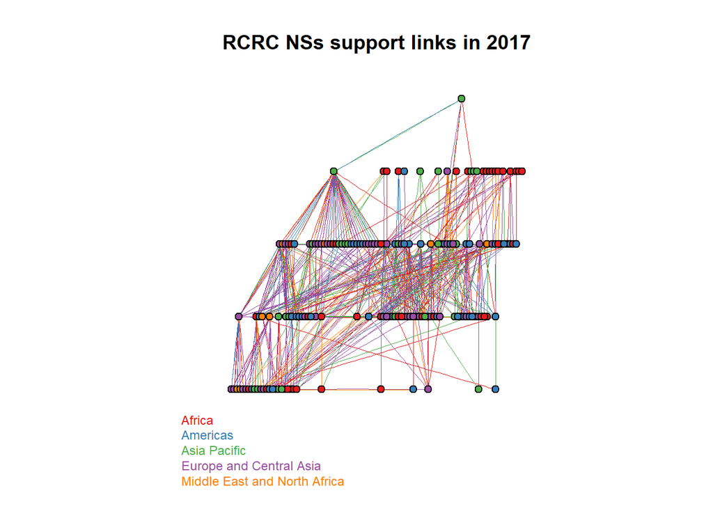

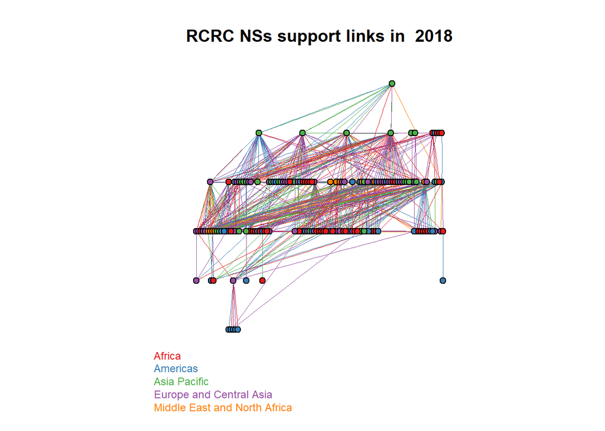

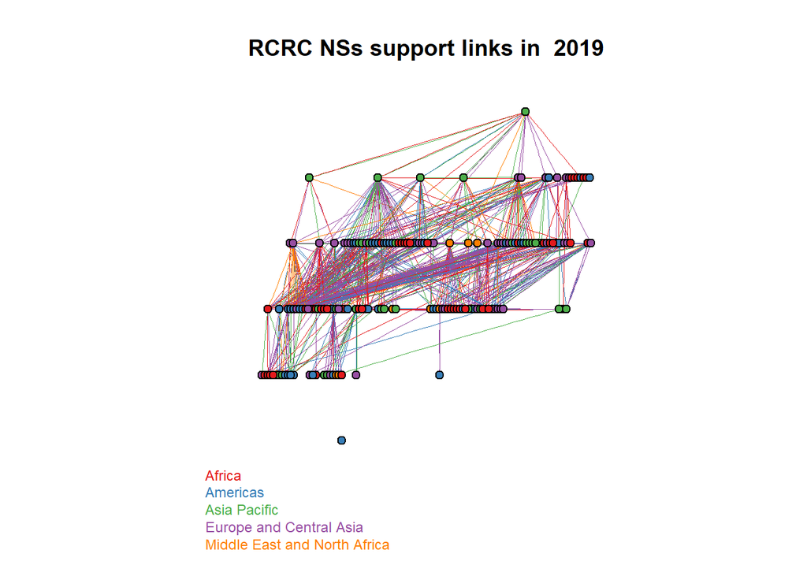

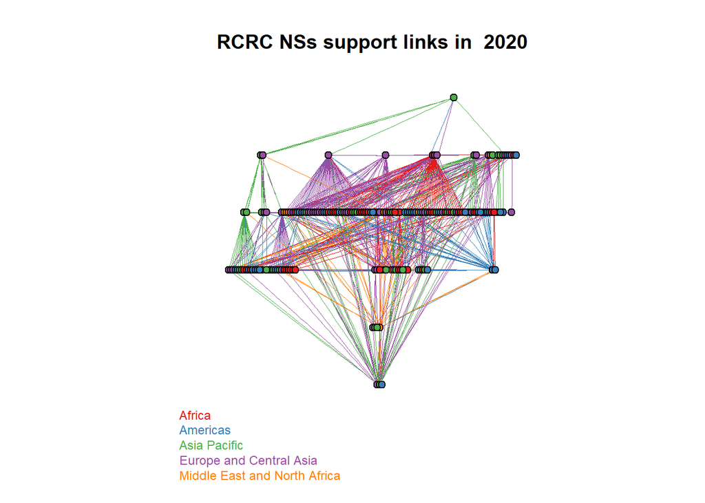

### Model specification

Following the RSiena manual, [Ruth M. Ripley et al (2021), p.44](http://www.stats.ox.ac.uk/~snijders/siena/RSiena_Manual.pdf), and [Snijders, Tom A B et al (2010)](https://www.sciencedirect.com/science/article/abs/pii/S0378873309000069) the parsimoniously model counted with the following **structural effects**: transitive closure, transitive ties effect, number of three-cycles, square indegree popularity, square outdegree activity and the elementary effects (reciprocity and outdegree). When it comes to covariates, the effects were chosen following the hypothesis stressed: in response to H4 region (constant covariate) similarity was included, ego related to NSs total income (H3) and alter crisis event and audited financial statement presence (H1 and H2 respectively).

```
Estimates, standard errors and convergence t-ratios

                                              Estimate   Standard    Convergence
                                                           Error       t-ratio
   1. rate constant RCRClinks rate (period 1) 832.0108 ( 1434.2295 )   -0.1279
   2. rate constant RCRClinks rate (period 2)  69.1016 (  197.5694 )   -0.0068
   3. rate constant RCRClinks rate (period 3)  72.7056 (  888.6033 )   -0.0651
   4. eval outdegree (density)                 -4.0016 (    3.8005 )    0.1913
   5. eval reciprocity                          2.2927 (    3.1230 )    0.1633
   6. eval transitive triplets                 -0.1906 (    0.0627 )    0.1514
   7. eval 3-cycles                             0.2187 (    0.8444 )    0.1499
   8. eval transitive ties                      0.4213 (    1.0068 )    0.1865
   9. eval indegree - popularity (sqrt)         0.5193 (    0.6636 )    0.1808
  10. eval outdegree - popularity (sqrt)       -0.4993 (    1.5878 )    0.1902
  11. eval outdegree - activity (sqrt)          0.3226 (    0.1211 )    0.1977
  12. eval region similarity                    0.0988 (    1.6822 )   -1.2867
  13. eval RCRCincome ego                       0.3545 (    3.2274 )   -0.1074
  14. eval crisis alter                        -0.0099 (    0.9981 )   -1.3575
  15. eval audited alter                        0.2355 (    0.0391 )    0.5002

Overall maximum convergence ratio:   11.1382


Total of 2162 iteration steps.
```

```
=========================================================
                                    Model 1
---------------------------------------------------------
constant RCRClinks rate (period 1)   832.01 (1434.23)
constant RCRClinks rate (period 2)    69.10  (197.57)
constant RCRClinks rate (period 3)    72.71  (888.60)
outdegree (density)                   -4.00    (3.80)
reciprocity                            2.29    (3.12)
transitive triplets                   -0.19    (0.06) **
3-cycles                               0.22    (0.84)
transitive ties                        0.42    (1.01)
indegree - popularity (sqrt)           0.52    (0.66)
outdegree - popularity (sqrt)         -0.50    (1.59)
outdegree - activity (sqrt)            0.32    (0.12) **
region similarity                      0.10    (1.68)
RCRCincome ego                         0.35    (3.23)
crisis alter                          -0.01    (1.00)
audited alter                          0.24    (0.04) ***
---------------------------------------------------------
Iterations                          2162
=========================================================
*** p < 0.001; ** p < 0.01; * p < 0.05
```

The first table above shows the convergence t-ratios and the maximum overall one. Ideally they should be lower than 0.1 and 0.25 respectively. The first model was also re-estimated using different initial values (using RSiena *prevAns*, but with no success as well). The estimates above show the statistically significant positive effect of the pull factor of NSs reporting audited financial statements and the structural effects such as transitive triplets and square outdegree as significants.

The main reason for the poor fit relies on the low Jaccard values (lower than 0.1 between waves whereas the ideal would be higher than at least 0.2 -[RSiena p.20](http://www.stats.ox.ac.uk/~snijders/siena/RSiena_Manual.pdf)). Therefore, the estimates above are not reliable and should be taken with caution or they indicate the need of another type of model or estimation method.

### Time heterogeneity

Another aspect that could lead to the poor fit of the model relates to time heterogeneity. Following [Etzh](https://ethz.ch/content/dam/ethz/special-interest/gess/social-networks-dam/documents/SIENA%20winter%20school%202016/Multiple_groups.pdf) and [Duke](https://sites.duke.edu/dnac/sienna-models/), a joint significance test higher than 0.05 indicates no time heterogeneity. Nevertheless, this is not the case for this model with a p < 0.0001. The graph below presents the effect-wise joint significance tests, the variables region and crisis have a p-value zeros. The usage of group dummies could improve the fit of the model.

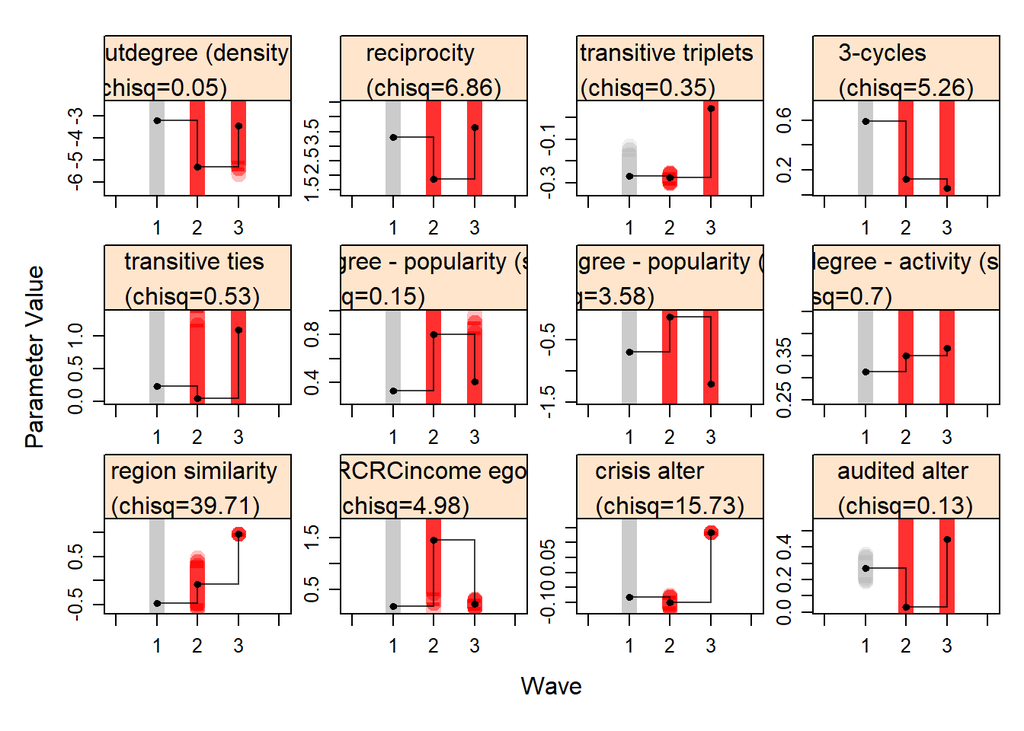

### Goodness of fit

The *SienaGOF* auxiliary compares the simulated model with the observed 2017-2020 networks. P-values over 0.05 suggests a reasonable fit. This is the case just for indegree distribution (p=0.63) as illustrated below.

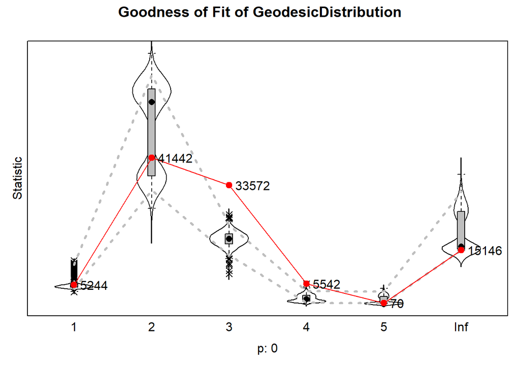

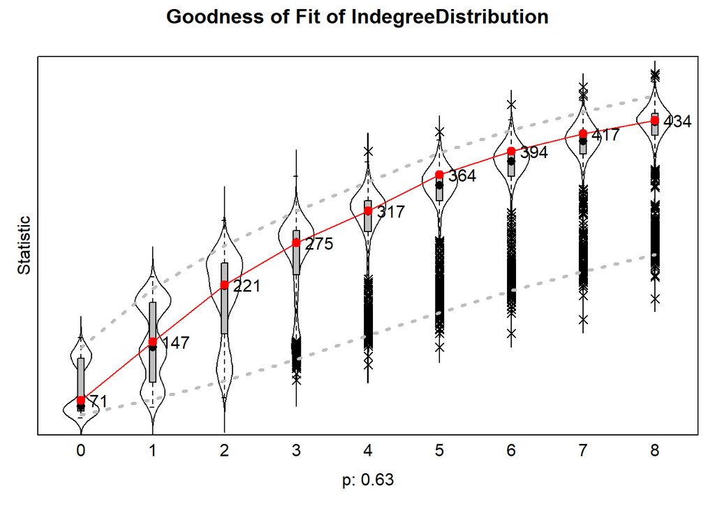

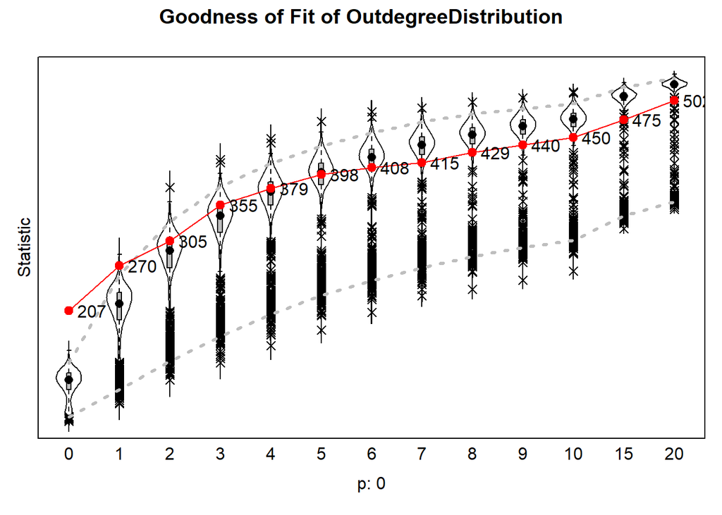

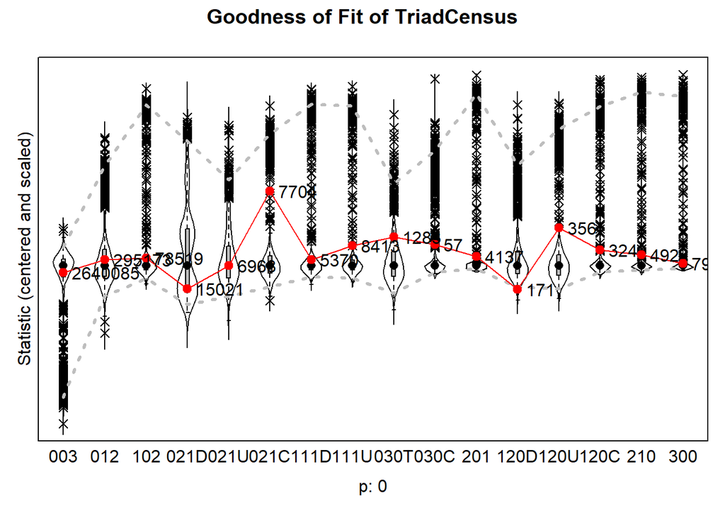

### Conclusion

In a nutshell, although the anecdotal evidence highlighted in the 4 hypothesis and the presence of some patterns in the network graphs presented, the models fitted proved to be of poor fit. Other effects should be introduced and some be replaced, the time heterogeneity could also be better explored. Nevertheless, given the needed time to run the models presented (6h-8h) such further exploration of the models is out of the scope of this assignment.